# Practical Machine Learning Project

Erico Santos

Saturday, January 17, 2015

## Human Activity Recognition (HAR)

This project aims to build a prediction model to guess how weel a lifting exercise was performed based on several variables collected by accelerometers (see details at http://groupware.les.inf.puc-rio.br/har).

## Data preparation and cleaning

There are 160 columns on the data set, so 159 possible predictors, some of them are factors with multiple levels which may yield yet more dummy variables. On a first cleaning step we will get rid of variables which have too many null values. A visual inspection on the data summary also shows several variables with the majority of occurences having a zero length character, which is equivalent to a null. We will also get rid of the variables related to subjects (name and number), with timestamps and window as those are assumed not relevant for the prediction objective.  
After these variables are removed we’re left with the “classe” variable (the prediction objective) plus the 52 predictors listed below.

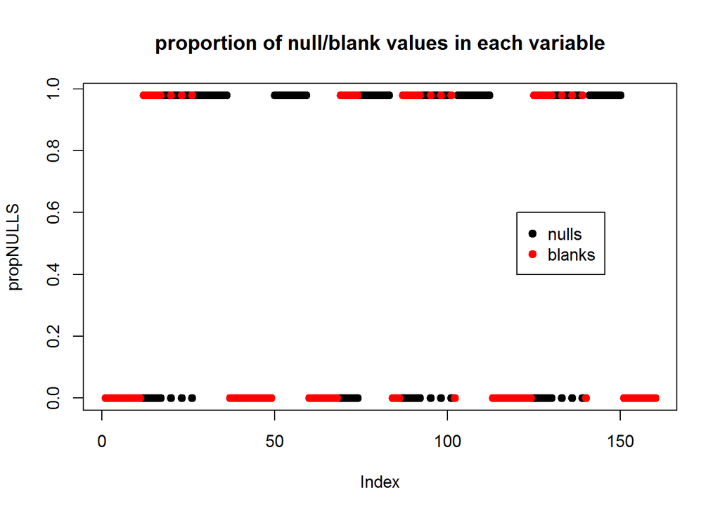

```r
library(caret)
training <- read.csv("data/pml-training.csv")
testing <- read.csv("data/pml-testing.csv")
# str(training)
# summary(training)
propNULLS<-apply(training,2,function(cc) mean(is.na(cc)))
propBlanks<-apply(training,2,function(cc) mean(cc==""))
plot(propNULLS,pch=19,main="proportion of null/blank values in each variable")
points(propBlanks,pch=19,col="red")
legend(120,.6,c("nulls","blanks"),pch=19,col = c("black","red"))
```

```r
# oldtraining<-training
training<-training[,!propNULLS>.8 & !propBlanks>.8]
## removing name/time/window factors
training<-training[,-c(1,2,3,4,5,6,7)]
names(training)
```

```
 [1] "roll_belt"            "pitch_belt"           "yaw_belt"             "total_accel_belt"
 [5] "gyros_belt_x"         "gyros_belt_y"         "gyros_belt_z"         "accel_belt_x"
 [9] "accel_belt_y"         "accel_belt_z"         "magnet_belt_x"        "magnet_belt_y"
[13] "magnet_belt_z"        "roll_arm"             "pitch_arm"            "yaw_arm"
[17] "total_accel_arm"      "gyros_arm_x"          "gyros_arm_y"          "gyros_arm_z"
[21] "accel_arm_x"          "accel_arm_y"          "accel_arm_z"          "magnet_arm_x"
[25] "magnet_arm_y"         "magnet_arm_z"         "roll_dumbbell"        "pitch_dumbbell"
[29] "yaw_dumbbell"         "total_accel_dumbbell" "gyros_dumbbell_x"     "gyros_dumbbell_y"
[33] "gyros_dumbbell_z"     "accel_dumbbell_x"     "accel_dumbbell_y"     "accel_dumbbell_z"
[37] "magnet_dumbbell_x"    "magnet_dumbbell_y"    "magnet_dumbbell_z"    "roll_forearm"
[41] "pitch_forearm"        "yaw_forearm"          "total_accel_forearm"  "gyros_forearm_x"
[45] "gyros_forearm_y"      "gyros_forearm_z"      "accel_forearm_x"      "accel_forearm_y"
[49] "accel_forearm_z"      "magnet_forearm_x"     "magnet_forearm_y"     "magnet_forearm_z"
[53] "classe"
```

## Model development and analysis

Having cleaned the dataset we proceed to testing some prediction models using the package caret. A first step is to create a cross validation set apart from the test data. As we have plenty of data we create a normal sampling with 70% of the data for training and 30% for testing/cross validation. We will base our model assessment on the out of sample error, that is, the error on the 30% cross validation data, so we avoid overfitting.

```r
## Create cross validation
trIndex = createDataPartition(training$classe, p = 0.70,list=FALSE)
trainingCV = training[trIndex,]
testingCV = training[-trIndex,]
# summary(trainingCV)
# table(training$classe)/sum(table(training$classe))
# table(trainingCV$classe)/sum(table(trainingCV$classe))
```

### Classification tree

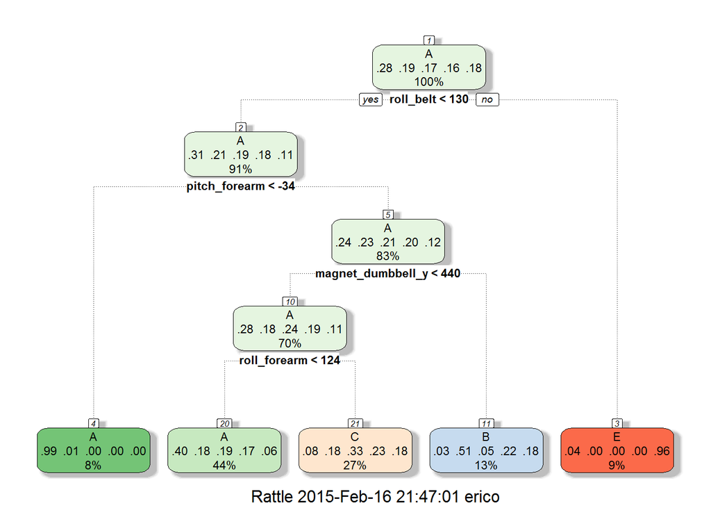

```r
## load pre-processed models (manual caching)
load("bkpModels") ## load m_rpart, m_rf, m_tb, ...
# m_rpart = train(classe ~ .,data=trainingCV,method="rpart")
# m_rpart$finalModel
# plot(m_rpart$finalModel)
# text(m_rpart$finalModel, use.n=TRUE, all=TRUE, cex=.8)
library(rattle)
library(rpart.plot)
fancyRpartPlot(m_rpart$finalModel)
```

```r
confusionMatrix(testingCV$classe,predict(m_rpart,testingCV))
```

```
Confusion Matrix and Statistics

          Reference
Prediction    A    B    C    D    E
         A 1503   23  125    0   23
         B  477  393  269    0    0
         C  469   30  527    0    0
         D  438  183  343    0    0
         E  143  156  280    0  503

Overall Statistics

               Accuracy : 0.4972
                 95% CI : (0.4843, 0.5101)
    No Information Rate : 0.5149
    P-Value [Acc > NIR] : 0.9968

                  Kappa : 0.3432
 Mcnemar's Test P-Value : NA

Statistics by Class:

                     Class: A Class: B Class: C Class: D Class: E
Sensitivity            0.4960  0.50064  0.34132       NA  0.95627
Specificity            0.9401  0.85373  0.88505   0.8362  0.89196
Pos Pred Value         0.8978  0.34504  0.51365       NA  0.46488
Neg Pred Value         0.6374  0.91740  0.79070       NA  0.99521
Prevalence             0.5149  0.13339  0.26236   0.0000  0.08938
Detection Rate         0.2554  0.06678  0.08955   0.0000  0.08547
Detection Prevalence   0.2845  0.19354  0.17434   0.1638  0.18386
Balanced Accuracy      0.7181  0.67718  0.61319       NA  0.92412
```

### Random forest

In the next test we run a random forest algorithm. This model takes more than 5 hours to train but yields a highly accurate result as can be seen in the confusion matrix below. Overall accuracy is more than 99% and sensitivity and specifity is above 99% for all classes.

```r
confusionMatrix(testingCV$classe,predict(m_rf,testingCV))
```

```
Confusion Matrix and Statistics

          Reference
Prediction    A    B    C    D    E
         A 1673    1    0    0    0
         B    4 1134    0    1    0
         C    0    2 1022    2    0
         D    0    0    3  961    0
         E    0    0    0    0 1082

Overall Statistics

               Accuracy : 0.9978
                 95% CI : (0.9962, 0.9988)
    No Information Rate : 0.285
    P-Value [Acc > NIR] : < 2.2e-16

                  Kappa : 0.9972
 Mcnemar's Test P-Value : NA

Statistics by Class:

                     Class: A Class: B Class: C Class: D Class: E
Sensitivity            0.9976   0.9974   0.9971   0.9969   1.0000
Specificity            0.9998   0.9989   0.9992   0.9994   1.0000
Pos Pred Value         0.9994   0.9956   0.9961   0.9969   1.0000
Neg Pred Value         0.9991   0.9994   0.9994   0.9994   1.0000
Prevalence             0.2850   0.1932   0.1742   0.1638   0.1839
Detection Rate         0.2843   0.1927   0.1737   0.1633   0.1839
Detection Prevalence   0.2845   0.1935   0.1743   0.1638   0.1839
Balanced Accuracy      0.9987   0.9982   0.9981   0.9981   1.0000
```

```r
# system.time({m_rf <- train(classe ~ .,data=trainingCV,method="rf",prox=T)})
## 5.2 hs
# plot(m_rf)
# m_rf$finalModel
```

Looking at the main variables considered by the random forest algorithm one can see that the first two variables are the same as in the first classification tree, but the random forest dentifies “yaw_belt” as the third most important variable while it is not even used in the tree. Other important variables are also left out of the first tree.

```r
varImp(m_rf)
```

```
rf variable importance

  only 20 most important variables shown (out of 52)

                     Overall
roll_belt             100.00
pitch_forearm          58.77
yaw_belt               56.39
magnet_dumbbell_z      46.20
pitch_belt             44.22
magnet_dumbbell_y      41.70
roll_forearm           41.49
accel_dumbbell_y       22.27
magnet_dumbbell_x      20.20
roll_dumbbell          17.46
accel_forearm_x        17.13
magnet_belt_z          15.16
accel_dumbbell_z       14.13
total_accel_dumbbell   14.04
accel_belt_z           13.97
magnet_belt_y          13.03
magnet_forearm_z       12.61
yaw_arm                11.42
gyros_belt_z           10.91
magnet_belt_x          10.35
```

### Bagging

A bagging model was also trained and yielded approximately the same accuracy as the random forest model (see confusion matrix and statistics below) but in only 26 minutes. The order of importance of the variables is different, although all the main variables are considered by both methods.

```r
# system.time({m_tb <- train(classe ~ .,data=trainingCV,method="treebag")})
## 26 min.
# m_tb$finalModel
confusionMatrix(testingCV$classe,predict(m_tb,testingCV))
```

```
Confusion Matrix and Statistics

          Reference
Prediction    A    B    C    D    E
         A 1670    2    2    0    0
         B    4 1134    1    0    0
         C    0    1 1021    4    0
         D    0    0    4  960    0
         E    0    0    0    0 1082

Overall Statistics

               Accuracy : 0.9969
                 95% CI : (0.9952, 0.9982)
    No Information Rate : 0.2845
    P-Value [Acc > NIR] : < 2.2e-16

                  Kappa : 0.9961
 Mcnemar's Test P-Value : NA

Statistics by Class:

                     Class: A Class: B Class: C Class: D Class: E
Sensitivity            0.9976   0.9974   0.9932   0.9959   1.0000
Specificity            0.9991   0.9989   0.9990   0.9992   1.0000
Pos Pred Value         0.9976   0.9956   0.9951   0.9959   1.0000
Neg Pred Value         0.9991   0.9994   0.9986   0.9992   1.0000
Prevalence             0.2845   0.1932   0.1747   0.1638   0.1839
Detection Rate         0.2838   0.1927   0.1735   0.1631   0.1839
Detection Prevalence   0.2845   0.1935   0.1743   0.1638   0.1839
Balanced Accuracy      0.9983   0.9982   0.9961   0.9975   1.0000
```

```r
varImp(m_tb)
```

```
treebag variable importance

  only 20 most important variables shown (out of 52)

                     Overall
roll_belt             100.00
yaw_belt               72.73
pitch_belt             70.74
magnet_dumbbell_y      69.79
pitch_forearm          66.68
roll_forearm           55.50
magnet_dumbbell_z      51.30
accel_dumbbell_y       49.20
roll_dumbbell          48.31
magnet_dumbbell_x      38.75
magnet_belt_y          35.41
accel_belt_z           33.93
magnet_belt_z          30.09
yaw_arm                28.05
accel_forearm_x        25.71
accel_dumbbell_z       24.94
gyros_belt_z           23.68
total_accel_dumbbell   22.14
magnet_belt_x          21.55
total_accel_belt       20.81
```

### Principal component analysis

Even though we already have two good models (random forest and bagging) one could also explore the possibility of increasing efficiency for an eventual repeated application. This could be done with pre-processing of the data. The testing with principal component analysis reveals that only 20 variables (out of the 52 left after cleaning) are sufficient to explain 90% of the variance. This could also be used to develop faster methods.

```r
prep <- preProcess(trainingCV[,-53],method = "pca",thresh = .9)
prep
```

```
Call:
preProcess.default(x = trainingCV[, -53], method = "pca", thresh = 0.9)

Created from 13737 samples and 52 variables
Pre-processing: principal component signal extraction, scaled, centered

PCA needed 20 components to capture 90 percent of the variance
```

```r
# rot <- as.data.frame(round(prep$rotation,3))
# save(m_rf,m_rpart,m_tb,file = "bkpModels")
```

### Predicting the test data

After training the models and finding high accuracy using the cross validation data we are confident to predict the test data using either the random forest or treebag models. The 20 test subjects are predicted to fall in the classes below. Both random forest and bagging models predict the same value for all test subjects.

```r
## subset fields of interest
fTesting <- testing[,names(training[,1:52])]
library(knitr)
kable(data.frame(problem_id=testing$problem_id
                 ,prediction_rf=predict(m_rf,fTesting)
                 ,prediction_tb=predict(m_tb,fTesting)),align="c")
```

| problem_id | prediction_rf | prediction_tb |
| --- | --- | --- |
| 1 | B | B |
| 2 | A | A |
| 3 | B | B |
| 4 | A | A |
| 5 | A | A |
| 6 | E | E |
| 7 | D | D |
| 8 | B | B |
| 9 | A | A |
| 10 | A | A |
| 11 | B | B |
| 12 | C | C |
| 13 | B | B |
| 14 | A | A |
| 15 | E | E |
| 16 | E | E |
| 17 | A | A |
| 18 | B | B |
| 19 | B | B |
| 20 | B | B |